# Income and Diabetes Mortality at the County Level

Trevor Reader

12 / 11 / 2025

# 1 Introduction

This project examines how income and health outcomes align across U.S. counties. The central question is: **Do counties with lower median household income show higher diabetes mortality?** This is a frequent question in policy discussions because diabetes is both preventable and unevenly distributed across communities.

The dataset used here is **synthetic**, designed to resemble county-level socioeconomic and health indicators. It includes:

- median household income
- diabetes mortality (deaths per 100,000 people)
- region
- urban vs. rural classification
- population size

Because the data are simulated, the goal is not to draw real-world conclusions. Instead, this serves as a demonstration of a clear, policy-oriented analysis workflow.

# 2 Data Overview

```r
df_raw <- read_csv("health_income_county.csv") %>%
  clean_names()

glimpse(df_raw)
```

```
## Rows: 300
## Columns: 7
## $ county             <chr> "County_0", "County_1", "County_2", "County_3", "Co…
## $ state              <chr> "NC", "TX", "SC", "CA", "NC", "MI", "AL", "NC", "SC…
## $ median_income      <dbl> 53468, 59099, 80426, 73558, 43605, 47837, 53665, 34…
## $ diabetes_mortality <dbl> 22.8, 26.6, 23.4, 31.5, 35.1, 29.3, 28.5, 22.7, 23.…
## $ population         <dbl> 436151, 52641, 44711, 347486, 384040, 158254, 10283…
## $ urban_rural        <chr> "Urban", "Urban", "Urban", "Rural", "Urban", "Urban…
## $ region             <chr> "South", "South", "Midwest", "Midwest", "South", "M…
```

```r
summary(df_raw)
```

```
##     county             state           median_income   diabetes_mortality
##  Length:300         Length:300         Min.   :14630   Min.   :11.30
##  Class :character   Class :character   1st Qu.:45931   1st Qu.:24.15
##  Mode  :character   Mode  :character   Median :54618   Median :28.70
##                                        Mean   :54471   Mean   :28.60
##                                        3rd Qu.:63883   3rd Qu.:33.02
##                                        Max.   :93244   Max.   :45.90
##    population     urban_rural           region
##  Min.   : 17050   Length:300         Length:300
##  1st Qu.:133138   Class :character   Class :character
##  Median :256932   Mode  :character   Mode  :character
##  Mean   :255736
##  3rd Qu.:379973
##  Max.   :492602
```

```r
df_raw %>%
  summarise(
    n_counties  = n(),
    mean_income = mean(median_income),
    sd_income   = sd(median_income),
    mean_diab   = mean(diabetes_mortality),
    sd_diab     = sd(diabetes_mortality)
  )
```

```
## # A tibble: 1 × 5
##   n_counties mean_income sd_income mean_diab sd_diab
##        <int>       <dbl>     <dbl>     <dbl>   <dbl>
## 1        300      54471.    12754.      28.6    6.45
```

# 3 Exploratory Analysis

## 3.1 Distribution of Median Income

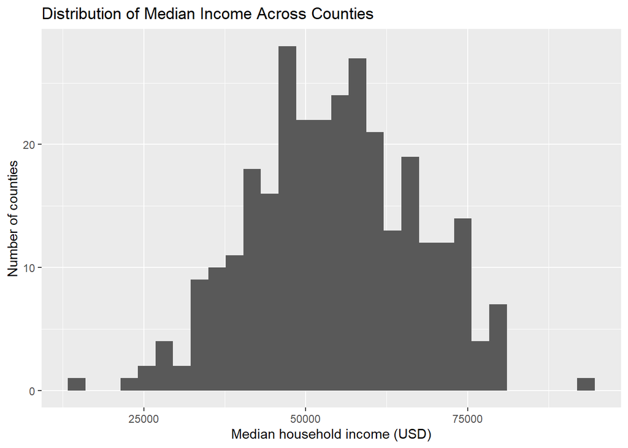

```r
df_raw %>%
  ggplot(aes(x = median_income)) +
  geom_histogram(bins = 30) +
  labs(
    title = "Distribution of Median Income Across Counties",
    x = "Median household income (USD)",
    y = "Number of counties"
  )
```

## 3.2 Distribution of Diabetes Mortality

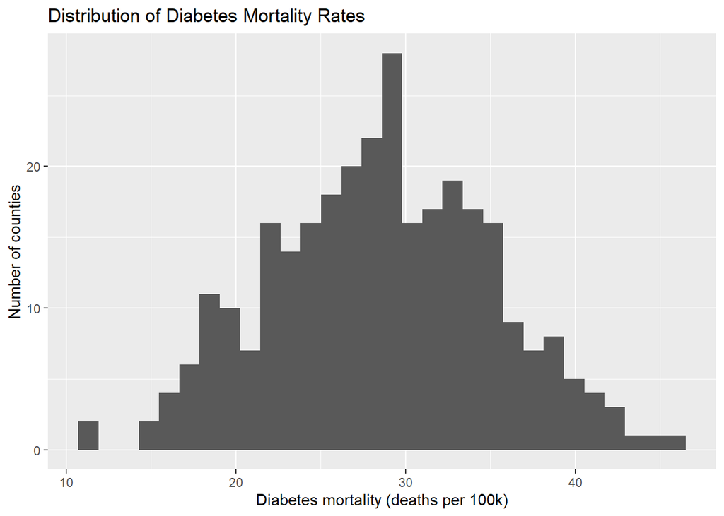

```r
df_raw %>%
  ggplot(aes(x = diabetes_mortality)) +
  geom_histogram(bins = 30) +
  labs(
    title = "Distribution of Diabetes Mortality Rates",
    x = "Diabetes mortality (deaths per 100k)",
    y = "Number of counties"
  )
```

## 3.3 Income vs. Diabetes Mortality

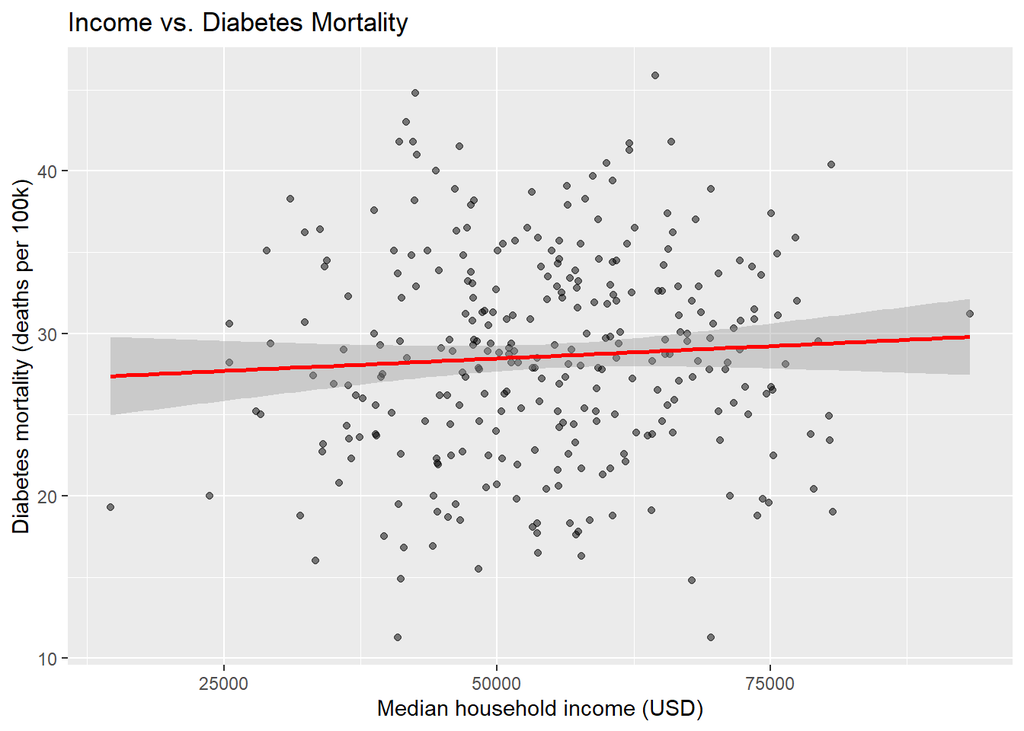

```r
df_raw %>%
  ggplot(aes(x = median_income, y = diabetes_mortality)) +
  geom_point(alpha = 0.5) +
  geom_smooth(method = "lm", se = TRUE, color = "red") +
  labs(
    title = "Income vs. Diabetes Mortality",
    x = "Median household income (USD)",
    y = "Diabetes mortality (deaths per 100k)"
  )
```

# 4 Modeling

## 4.1 Simple Linear Regression

```r
model_simple <- lm(diabetes_mortality ~ median_income, data = df_raw)
summary(model_simple)
```

```
##
## Call:
## lm(formula = diabetes_mortality ~ median_income, data = df_raw)
##
## Residuals:
##      Min       1Q   Median       3Q      Max
## -17.7651  -4.4304   0.1667   4.4217  16.9901
##
## Coefficients:
##                Estimate Std. Error t value Pr(>|t|)
## (Intercept)   2.693e+01  1.636e+00  16.462   <2e-16 ***
## median_income 3.064e-05  2.925e-05   1.048    0.296
## ---
## Signif. codes:  0 '***' 0.001 '**' 0.01 '*' 0.05 '.' 0.1 ' ' 1
##
## Residual standard error: 6.451 on 298 degrees of freedom
## Multiple R-squared:  0.003669,   Adjusted R-squared:  0.0003257
## F-statistic: 1.097 on 1 and 298 DF,  p-value: 0.2957
```

The coefficient on income is small and not statistically significant. The R-squared value is near zero, meaning income explains little of the variation in diabetes mortality.

## 4.2 Mortality by Region

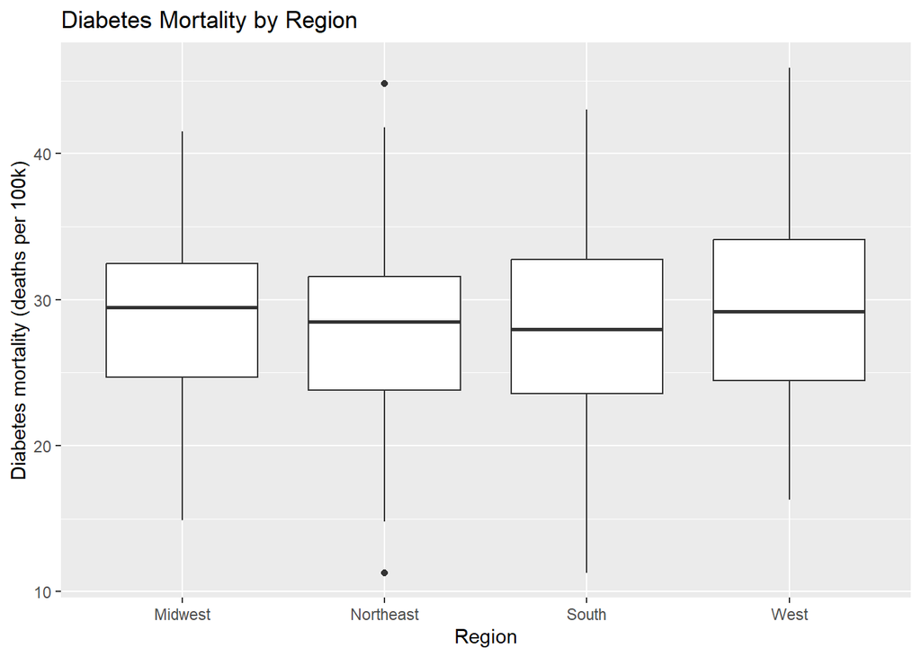

```r
df_raw %>%
  ggplot(aes(x = region, y = diabetes_mortality)) +
  geom_boxplot() +
  labs(
    title = "Diabetes Mortality by Region",
    x = "Region",
    y = "Diabetes mortality (deaths per 100k)"
  )
```

## 4.3 Urban vs. Rural Differences

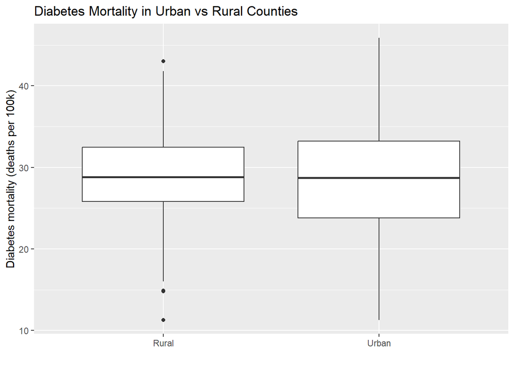

```r
df_raw %>%
  ggplot(aes(x = urban_rural, y = diabetes_mortality)) +
  geom_boxplot() +
  labs(
    title = "Diabetes Mortality in Urban vs Rural Counties",
    x = "",
    y = "Diabetes mortality (deaths per 100k)"
  )
```

## 4.4 Multivariable Regression

```r
model_multi <- lm(
  diabetes_mortality ~ median_income + region + urban_rural,
  data = df_raw
)
summary(model_multi)
```

```
##
## Call:
## lm(formula = diabetes_mortality ~ median_income + region + urban_rural,
##     data = df_raw)
##
## Residuals:
##     Min      1Q  Median      3Q     Max
## -17.739  -4.416   0.277   4.270  16.627
##
## Coefficients:
##                    Estimate Std. Error t value Pr(>|t|)
## (Intercept)       2.660e+01  1.907e+00  13.952   <2e-16 ***
## median_income     3.388e-05  2.949e-05   1.149    0.252
## regionNortheast   8.206e-02  1.063e+00   0.077    0.939
## regionSouth      -4.230e-01  1.053e+00  -0.402    0.688
## regionWest        8.766e-01  1.084e+00   0.809    0.419
## urban_ruralUrban  5.017e-02  8.296e-01   0.060    0.952
## ---
## Signif. codes:  0 '***' 0.001 '**' 0.01 '*' 0.05 '.' 0.1 ' ' 1
##
## Residual standard error: 6.477 on 294 degrees of freedom
## Multiple R-squared:  0.008845,   Adjusted R-squared:  -0.008012
## F-statistic: 0.5247 on 5 and 294 DF,  p-value: 0.7575
```

Income, region, and urban/rural status all remain weak predictors, and the model’s explanatory power stays low.

# 5 Policy Interpretation

If these results came from real county-level data, they would suggest:

- Income does not reliably predict diabetes mortality
- Region and urban/rural status add little explanatory value
- Policymakers would need more detailed variables (e.g., demographics, insurance coverage, health behaviors, access to care) to make targeted decisions

The muted patterns here reflect the **synthetic** nature of the dataset rather than real-world disease burden, which usually shows stronger socioeconomic gradients.

# 6 Limitations

- The dataset is synthetic; results cannot be generalized
- Important predictors of diabetes mortality (age distribution, obesity rates, clinical access, etc.) are missing
- Linear modeling may oversimplify complex relationships

# 7 Conclusion

This project demonstrates a clean, complete workflow for analyzing county-level health disparities:

- importing and preparing data
- exploring variable distributions
- fitting regression models
- interpreting findings in a policy context

Although this synthetic dataset does not show strong relationships between income and diabetes mortality, the workflow shown here applies directly to real public datasets such as Census ACS indicators, CDC mortality files, or County Health Rankings.

# 8 Reproducibility

- Data file: `health_income_county.csv`
- R version: 4.5.2
- Key packages: `tidyverse`, `janitor`

Running this R Markdown file with the dataset in the same directory will reproduce all results and visualizations.